# Lesson 14: Inference for Several Means (ANOVA)

Homework

- Word Document
- PDF Document

## Solutions

Problem

Part

Solution

1

-

ANOVA is a test for equality of several means. It allows us to compare the means for several groups in one hypothesis test.

2

-

a. An *F*-distribution is right skewed. A *t*-distribution is bell-shaped.  
b. The values of *F* are never negative. The values of *t* can be positive or negative.  
c. The P-value for the ANOVA test is always the area in the right tail in an *F*-distribution. We will never divide the area in the tail. The P-value for a *t*-test can be either the area under the right tail, the left tail, or both.

3

-

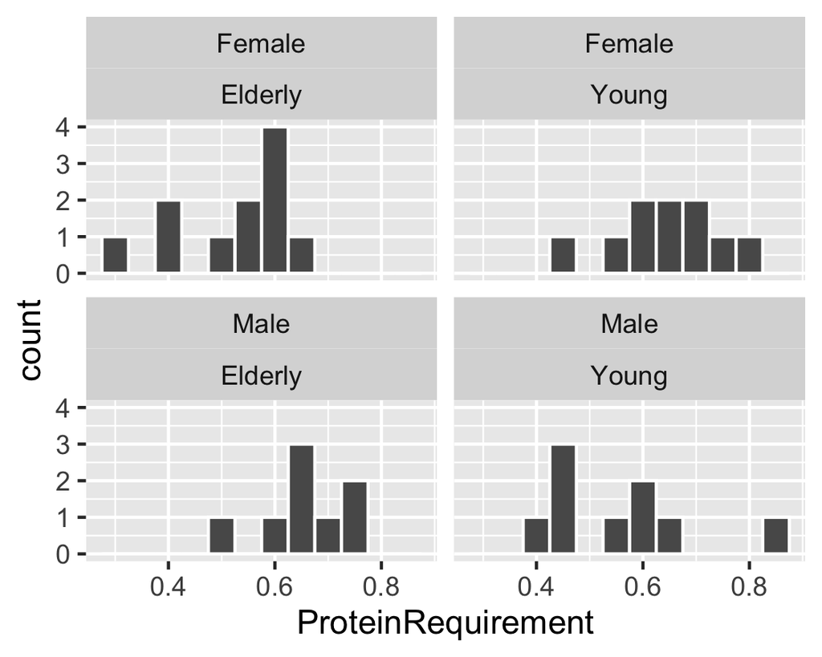

4

-

**Elderly Females**: n = 11, mean = 0.528, Std. Dev. = 0.112  
**Young Females**: n = 10, mean = 0.645, Std. Dev. = 0.099  
**Elderly Males**: n = 8, mean = 0.654, Std. Dev. = 0.092  
**Young Males**: n = 9, mean = 0.558, Std. Dev. = 0.145

5

-

ANOVA

6

-

Yes, the requirements are satisfied. The requirements that were checked were the following:  
-The observations are normally distributed within each group. This was checked by creating histograms for each group. The sample sizes are small and this conclusion is subjective.

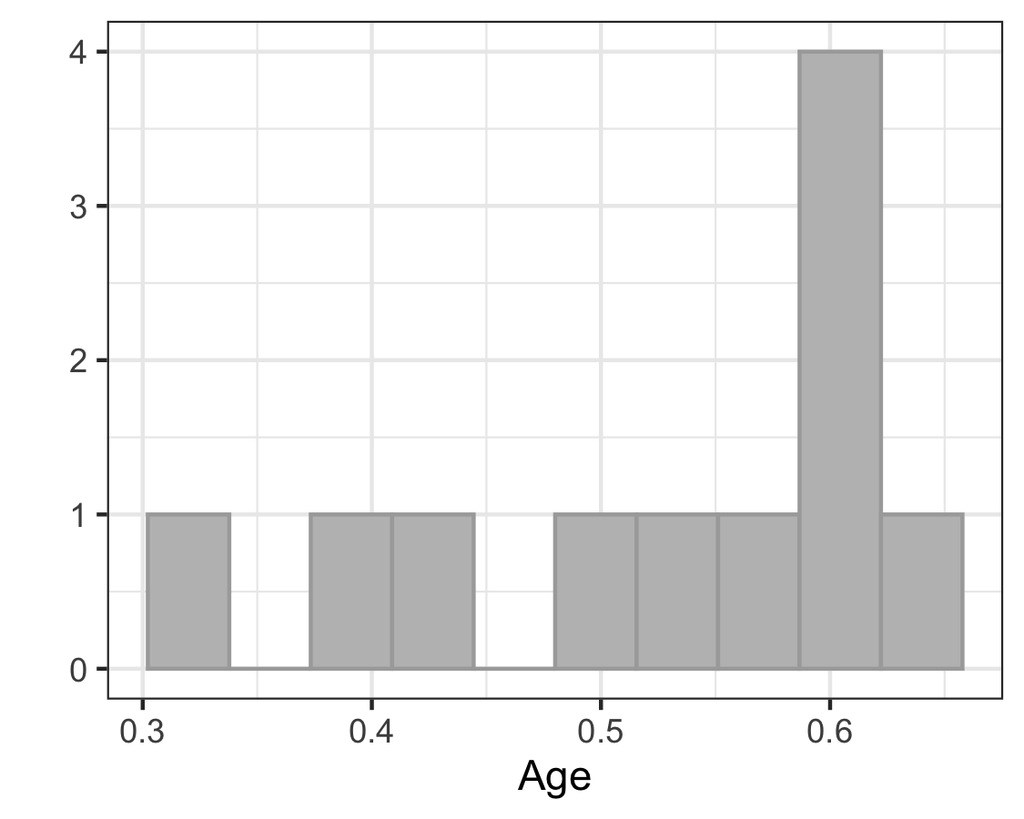

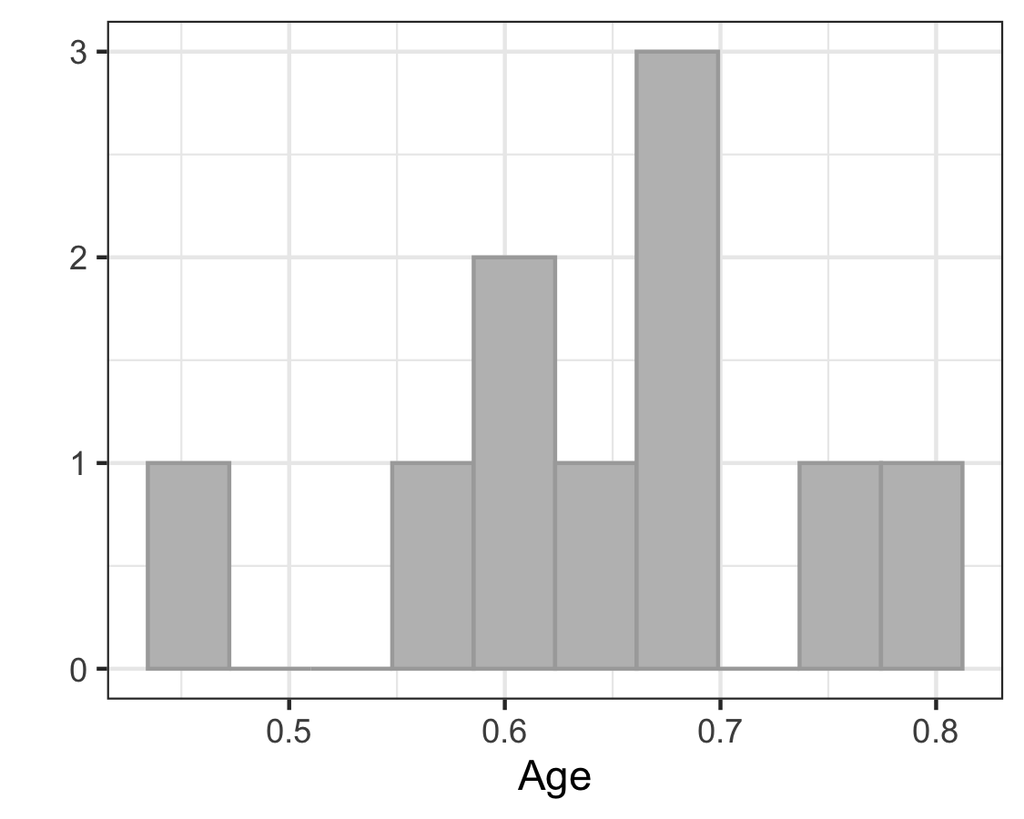

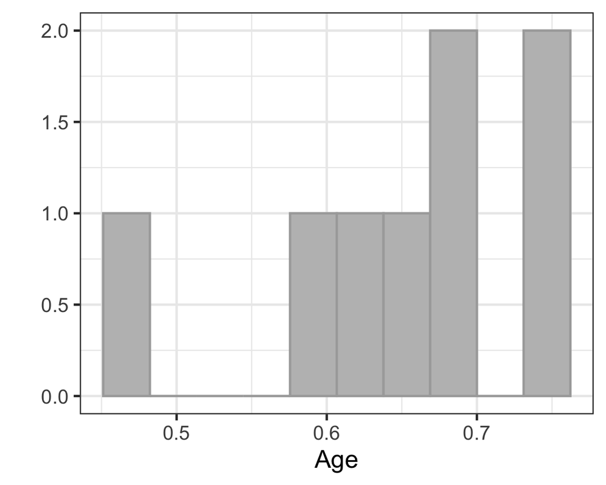

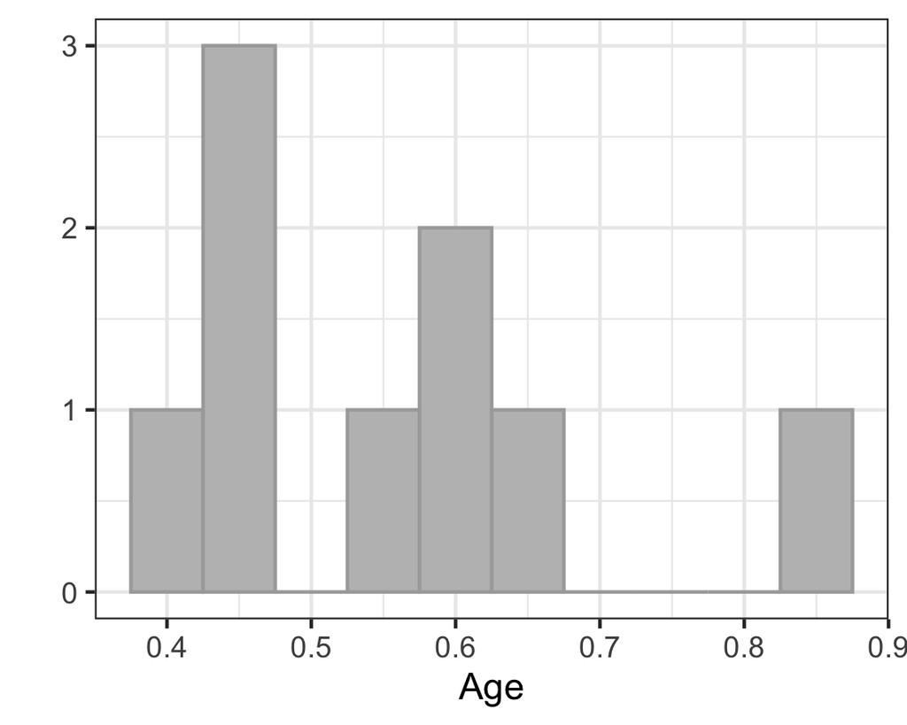

-The variances are equal. This was checked by noting that the largest variance is not more than four times the smallest variance.

7

-

$H_0: \text{All the means are equal}$  
$H_a: \text{At least one of the means differs}$

8

-

F = 2.932  
df = 3 and 34

9

-

P-value = 0.047

10

-

P-value = 0.047 < 0.05 = $\alpha$  
reject the null hypothesis

11

-

There is sufficient evidence to suggest that there is a difference in the mean protein requirements of the individuals in the four groups.

12

-

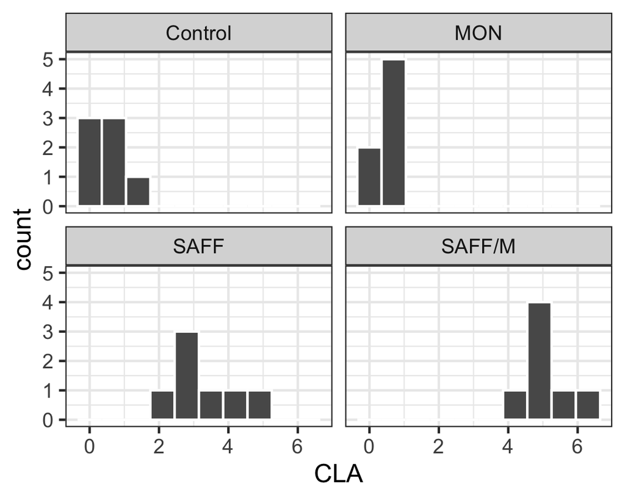

13

-

**Control**: n = 7, mean = 0.453, Std. Dev. = 0.391  
**MON**: n = 7, mean = 0.521, Std. Dev. = 0.325  
**SAFF**: n = 7, mean = 3.363, Std. Dev. = 0.774  
**SAFF/MON**: n = 7, mean = 5.151, Std. Dev. = 0.729

14

-

No, not all of the requirements are satisfied. The requirements that were checked were the following:  
-The observations are normally distributed within each group. This was checked by creating histograms for each group. The sample sizes are small and this conclusion is subjective.

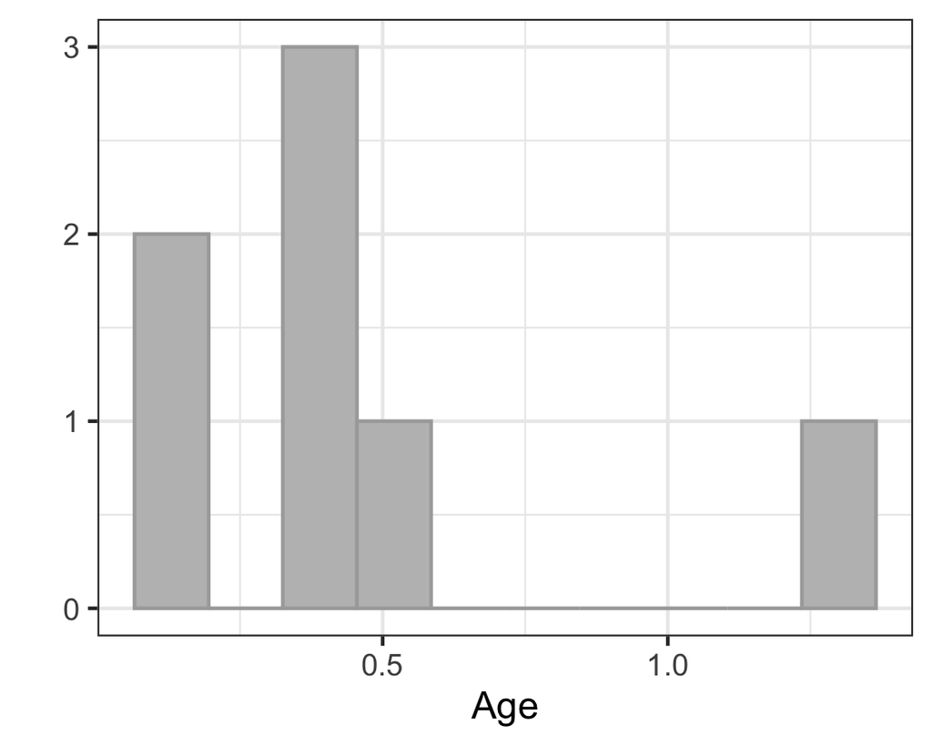

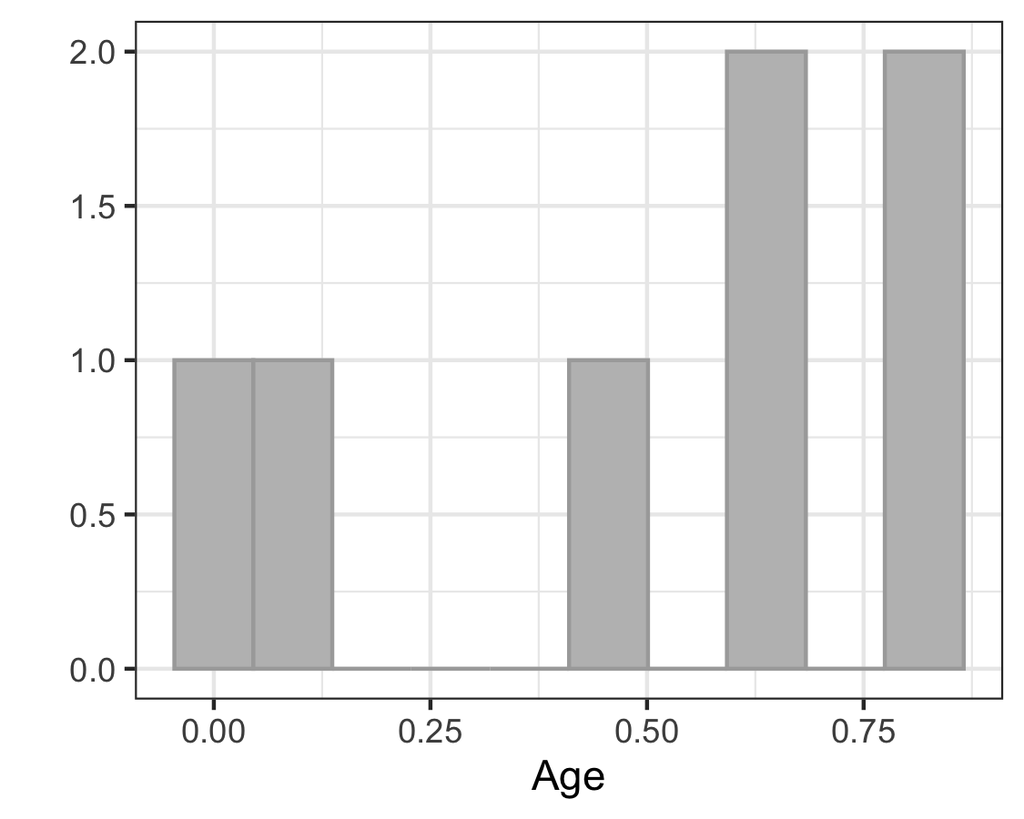

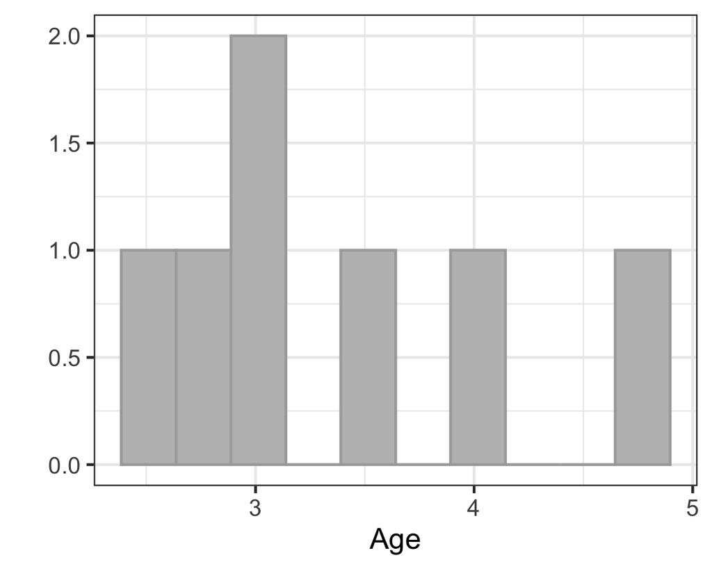

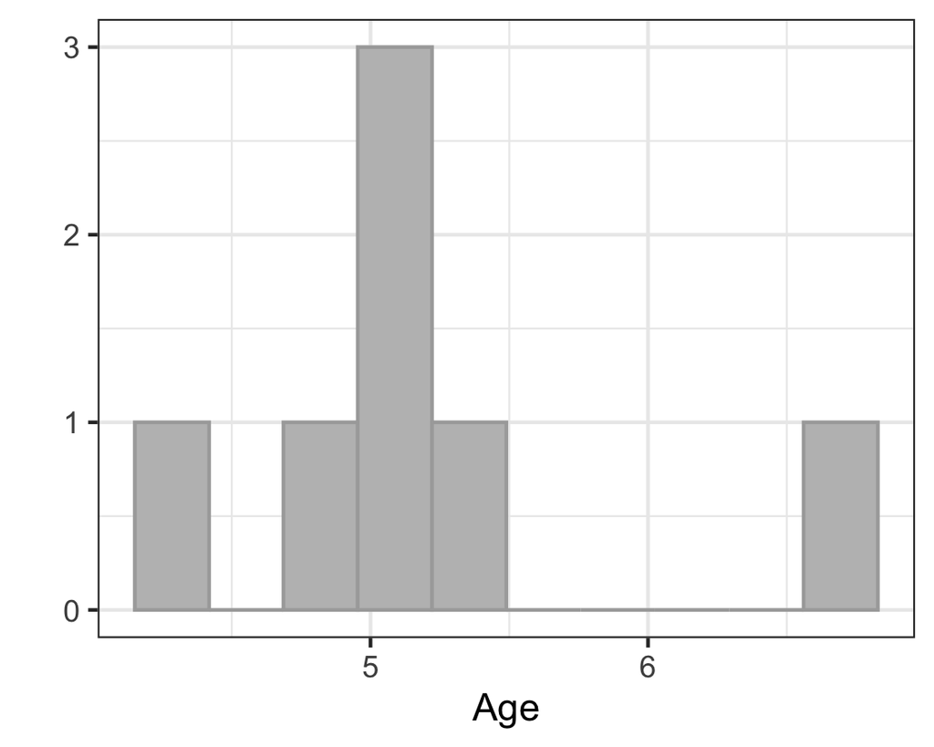

-The variances are not equal. This was checked by noting that the largest variance is more than four times the smallest variance.

15

-

$H_0: \text{All the means are equal}$  
$H_a: \text{At least one of the means differs}$

16

-

F = 106.217  
df = 3 and 24

17

-

P-value = 0

18

-

P-value = 0 < 0.05 = $\alpha$  
reject the null hypothesis

19

-

There is sufficient evidence to suggest that there is a difference in the mean CLA content in milk fat for at least one of the four diets.

20

-

It would be worth figuring out which of the diets produced the highest CLA content and then possibly encouraging the use of that diet more than the others.